# GenomicPlot: an R package for efficient and flexible visualization of NGS coverage profiles

Shuye Pu

2022-10-20

## Introduction

Visualization of next generation sequencing (NGS) data at various genomic features on a genome-wide scale provides a effective way of exploring and communicating experimental results on one hand, yet poses as a tremendous challenge on the other hand, due to the huge amount of data to be processed. Existing software tools like deeptools, ngs.plot and metagene2, while having attractive features and perform reasonably well in relatively simple scenarios, like plotting coverage profiles of fixed genomic loci or regions, have serious limitations in terms of efficiency and flexibility. For instance, deeptools requires 3 steps (3 sub-programs to be run) to generate plots from input files: first, convert .bam files to .bigwig format; second, compute coverage matrix; and last, plot genomic profiles. Huge amount of intermediate data are generated along the way and additional efforts have to be made to integrate these 3 closely related steps. All of them focus on plotting signals within genomic regions or around genomic loci, but not within or around combinations of genomic features. None of them have the capability of performing statistical tests on the data displayed in the profile plots.

To meet the diverse needs of experimental biologists, we have developed GenomicPlot using rich resources available on the R platform (particularly, the Bioconductor). Our GenomicPlot has the following major features:

- Generates genomic or metagenomic (without introns) plots around gene body and its upstream and downstream regions, the gene body can be further segmented into 5’ UTR, CDS and 3’ UTR
- Plots genomic profiles around the start and end of genomic features (like exon or intron), or custom defined genomic regions
- Plots distance between sample peaks and genomic features, or distance between one set of peaks to another set of peaks
- All profile line plots have error bands
- Random features can be generated and plotted to serve as contrast to real features
- Statistical analysis results on user defined regions are plotted along with the profile plots

## Plot metagene with 5’UTR, CDS and 3’UTR

The lengths of each part of the genes are prorated based on the median length of 5’UTR, CDS and 3’UTR of protein-coding genes in the genome. The total length (including upstream and downstream extensions) are divided into the specified number of bins.

```r
library(GenomicPlot, quietly=TRUE)
txdb <- AnnotationDbi::loadDb(system.file("data", "txdb_chr19.sql", package="GenomicPlotData"))
gf <- prepare_5parts_genomic_features(txdb, meta=TRUE, nbins=100, fiveP=500, threeP=500,
                                      longest=TRUE)
```

```
#> [1] "Preparing genomic features ... "
#> [1] "median sizes for features"
#> -0.5K 5'UTR   CDS 3'UTR  0.5K
#>   500   153  1287   450   500
#> [1] "bin sizes for features"
#> -0.5K 5'UTR   CDS 3'UTR  0.5K
#>    17     5    45    16    17
#> [1] "number of transcripts"
#> -0.5K 5'UTR   CDS 3'UTR  0.5K
#>  1282  1282  1282  1282  1282
```

```
#> [1] "Reading bam file: query"
#> 1e+06 2e+06 3e+06 3868102
#> [1] "Reading bam file: input"
#> 236278
#> [1] "Estimating size factor"
#> [1] "Library size normalizing factors:"
#> [1] 1.1448906 0.8734459
#> [1] "computing coverage for query files"
#> [1] "Preparing data for individual plotting"
#> [1] "Imputing missing values. Matrix quartiles:"
#>          0%         25%         50%         75%        100%
#>   0.0000000   0.1712432   1.4418174   4.7052314 561.0640212
#> Imputed value 0.00063429042489611
#> 42 all 0 rows are removed!
#> [1] "Imputing missing values. Matrix quartiles:"
#>           0%          25%          50%          75%         100%
#>     0.000000     0.000000     0.000000     4.845525 10799.997166
#> Imputed value 0.0106261505995869
#> 149 all 0 rows are removed!
#> [1] "Start plotting"
#> [1] "Preparing data for ratio plotting"
#> [1] "Imputing missing values. Matrix quartiles:"
#>          0%         25%         50%         75%        100%
#>   0.0000000   0.0000000   0.0000000   0.1408812 385.4154411
#> Imputed value 7.97966201700275e-05
#> 206 all 0 rows are removed!
#> [1] "plot_5parts_metagene runs successfully!"
```

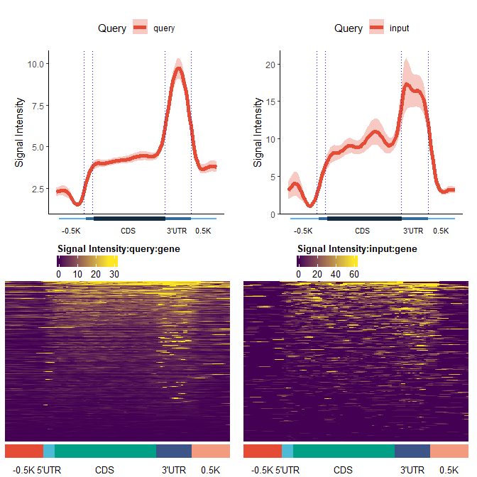

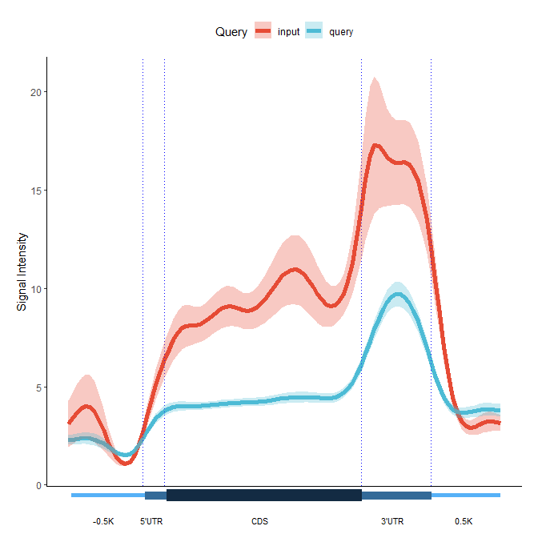

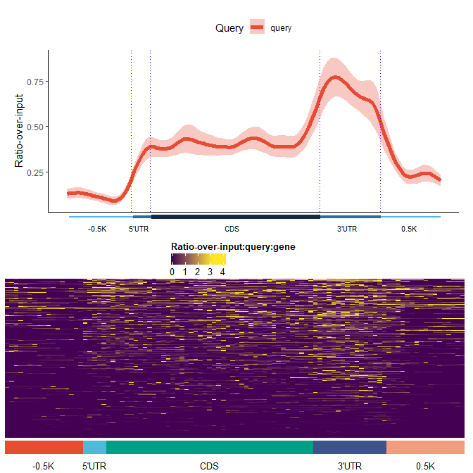

```r
queryfiles <- system.file("data", "test_clip_chr19.bam", package="GenomicPlotData")
names(queryfiles) <- "query"
inputfiles <- system.file("data", "test_clip_input_chr19.bam", package="GenomicPlotData")
names(inputfiles) <- "input"

handleInputParams <- list(CLIP_reads=FALSE, fix_width=150, fix_point="start", norm=TRUE,
                          useScore=FALSE, outRle=TRUE, useSizeFactor=TRUE, genome="hg19")

plot_5parts_metagene(queryfiles, gFeatures=gf, inputfiles=inputfiles, scale=FALSE, verbose=FALSE,
                     transform=FALSE, smooth=TRUE, stranded=TRUE, outPrefix=NULL,
                     handleInputParams=handleInputParams, heatmap=TRUE, rmOutlier=TRUE, nc=5)
```

## Plot metagene

The lengths of each part of the profile plot are prorated to the lengths of upstream and downstream extensions as well as the median length of protein-coding genes in the genome. The total length (including upstream and downstream extensions) are divided into the specified number of bins.

```r
gf <- prepare_3parts_genomic_features(txdb, meta=FALSE, nbins=100, fiveP=3000, threeP=2000,
                                      longest=TRUE)
```

```
#> [1] "Preparing features ..."
#> [1] "median sizes for features"
#> promoter               TTS
#>     3000    15564     2000
#> [1] "bin sizes for features"
#>  -3K gene   2K
#>   15   76   10
#> [1] "number of transcripts"
#>  -3K gene   2K
#> 1485 1485 1485
```

```
#> [1] "-3K"  "gene" "2K"
#>  -3K gene   2K
#> 1485 1485 1485
#> [1] "computing coverage for queryfiles"
#> [1] "Reading bam file: query"
#> Paired end bam file detected!
#> [1] "Reading bam file: input"
#> Paired end bam file detected!
#> [1] "Estimating size factor"
#> [1] "Library size normalizing factors:"
#> [1] 0.9039083 1.1063069
#> [1] "-3K"
#> [1] "gene"
#> [1] "2K"
#> [1] "-3K"
#> [1] "gene"
#> [1] "2K"
#> [1] "plotting coverage for queryfiles"
#> [1] "Imputing missing values. Matrix quartiles:"
#>          0%         25%         50%         75%        100%
#>    0.000000    0.461486    1.475986    3.482025 1034.408926
#> Imputed value 0.000509466675407756
#>
#> [1] "-3K"
#> [1] "gene"
#> [1] "2K"
#> Warning in `[<-`(`*tmp*`, dataname, value = new("Heatmap", name = "Signal
#> Intensity:query:gene", : implicit list embedding of S4 objects is deprecated
#> [1] "Imputing missing values. Matrix quartiles:"
#>         0%        25%        50%        75%       100%
#>  0.0000000  0.8560566  1.8080836  3.2757920 35.8978769
#> Imputed value 0.000582521813263275
#>
#> [1] "-3K"
#> [1] "gene"
#> [1] "2K"
#> 1 all 0 rows are removed!
#> Warning in `[<-`(`*tmp*`, dataname, value = new("Heatmap", name = "Signal
#> Intensity:input:gene", : implicit list embedding of S4 objects is deprecated
#> [1] "computing coverage for ratio over input"
#> [1] "plotting coverage for ratio over input"
#> [1] "Imputing missing values. Matrix quartiles:"
#>           0%          25%          50%          75%         100%
#>    0.0000000    0.1647141    0.7488761    1.7019437 4009.3164631
#> Imputed value 0.000207816069723615
#>
#> [1] "-3K"
#> [1] "gene"
#> [1] "2K"
#> Warning in `[<-`(`*tmp*`, dataname, value = new("Heatmap", name = "Ratio-over-
#> input:query:gene", : implicit list embedding of S4 objects is deprecated
```

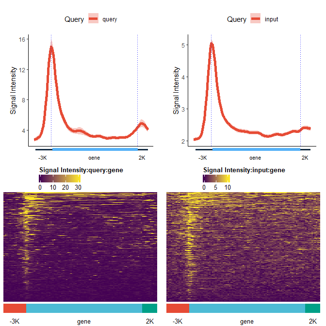

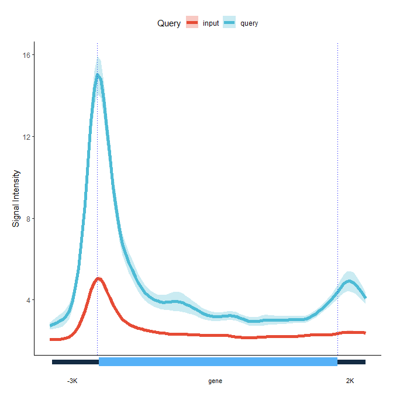

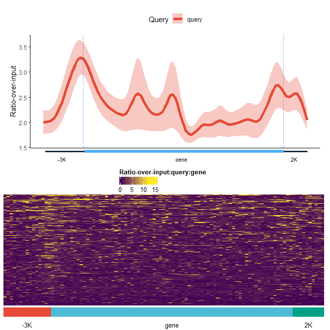

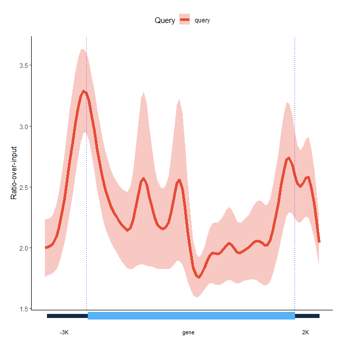

```r
queryfiles <- system.file("data", "test_chip_chr19.bam", package="GenomicPlotData")
names(queryfiles) <- "query"
inputfiles <- system.file("data", "test_chip_input_chr19.bam", package="GenomicPlotData")
names(inputfiles) <- "input"

handleInputParams <- list(CLIP_reads=FALSE, fix_width=150, fix_point="start", norm=TRUE,
                          useScore=FALSE, outRle=TRUE, useSizeFactor=TRUE, genome="hg19")

plot_3parts_metagene(queryfiles, gFeatures=gf, inputfiles=inputfiles, scale=FALSE, verbose=FALSE,
                     transform=FALSE, smooth=TRUE, stranded=TRUE, outPrefix=NULL,
                     handleInputParams=handleInputParams, heatmap=TRUE, rmOutlier=TRUE, nc=5)
```

## Plot user defined regions

Signal profile in user defined regions provided through a .bed file or narrowPeak file along with heatmaps can be plotted. Multiple samples (.bam files) and multiple set of regions (.bed file) can over-layed on the same figure, or can be output as various combinations. When input files (for ChIPseq and CLIPseq) are available, ratio-over-input are displayed as well.

[output not shown]

[output cut: 223 more lines]

[output not shown]

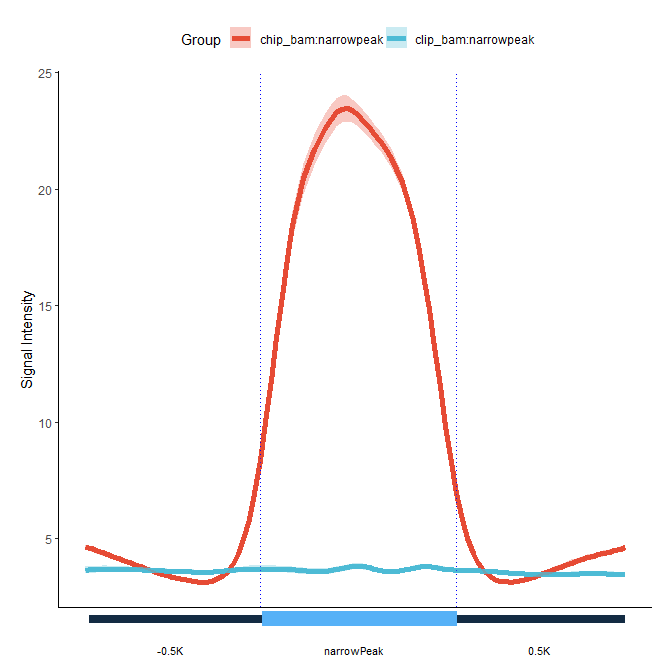

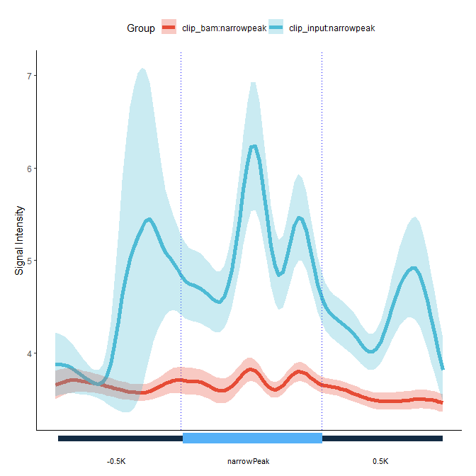

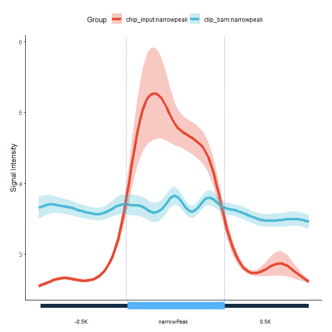

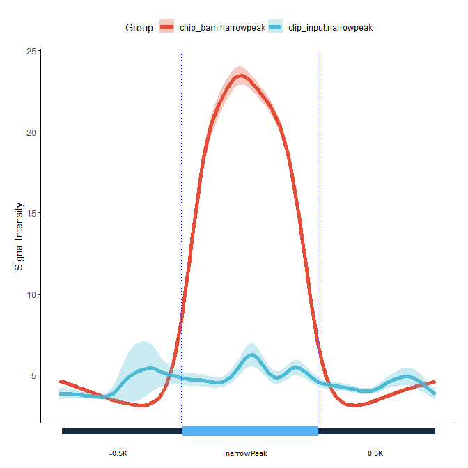

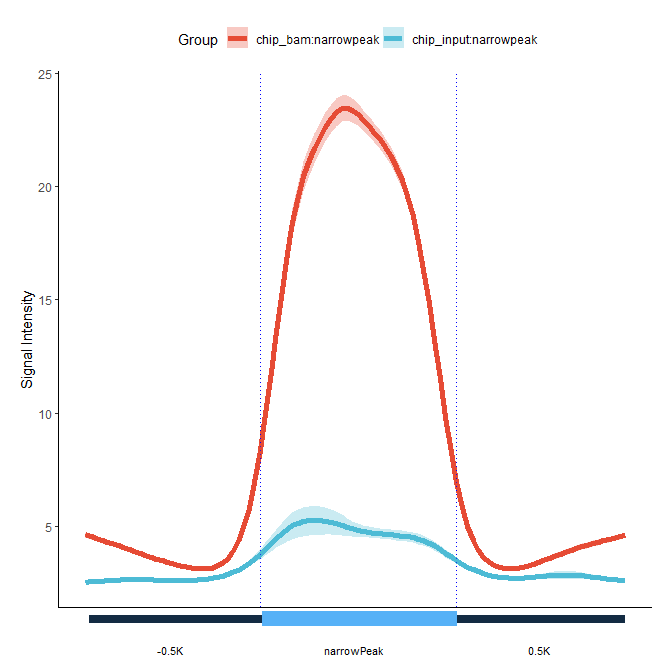

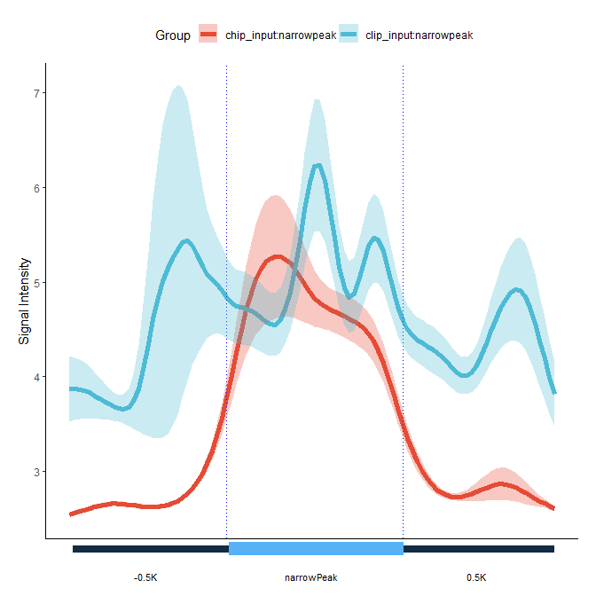

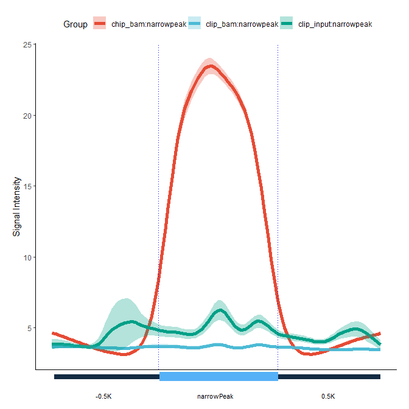

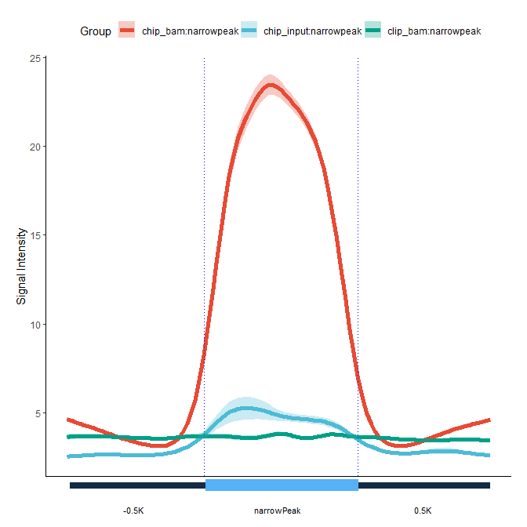

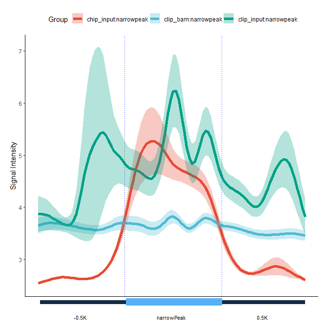

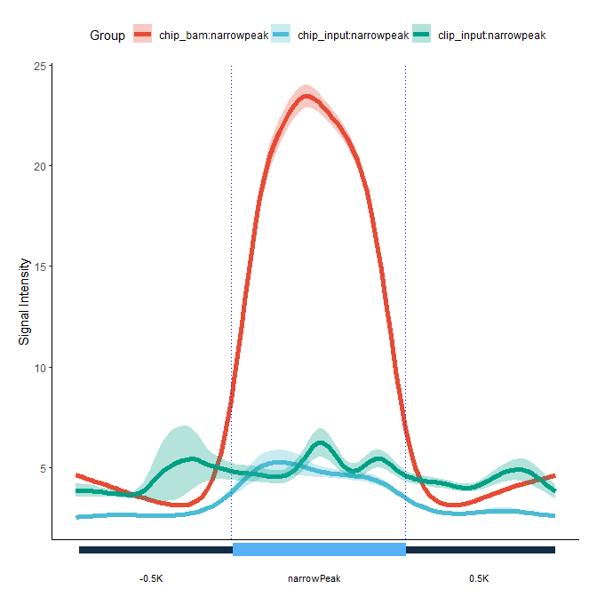

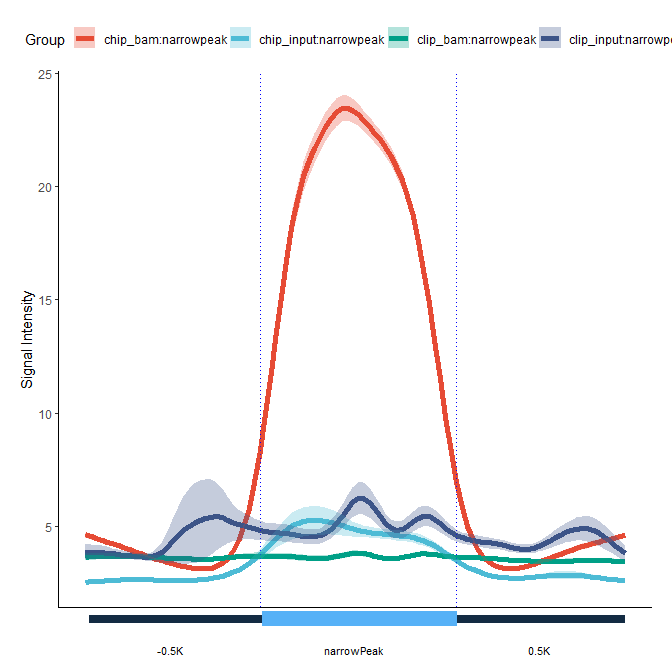

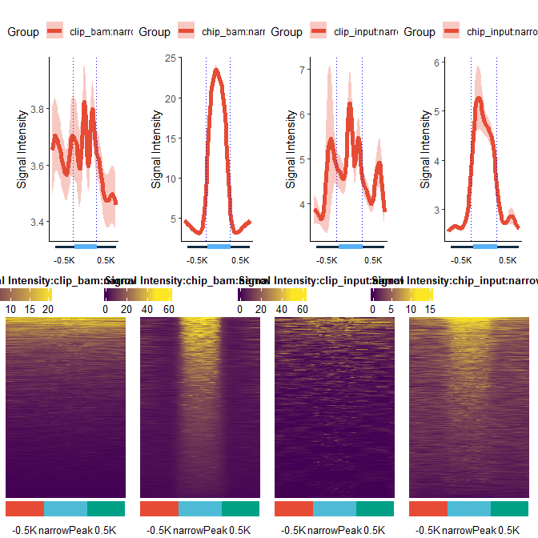

[2 more figures not shown]

```r
centerfiles <- system.file("data", "test_chip_peak_chr19.narrowPeak", package="GenomicPlotData")
 names(centerfiles) <- c("narrowpeak")
 queryfiles <- c(system.file("data", "test_clip_chr19.bam", package="GenomicPlotData"),
                 system.file("data", "test_chip_chr19.bam", package="GenomicPlotData"))
 names(queryfiles) <- c("clip_bam", "chip_bam")
 inputfiles <- c(system.file("data", "test_clip_input_chr19.bam", package="GenomicPlotData"),
                 system.file("data", "test_chip_input_chr19.bam", package="GenomicPlotData"))
 names(inputfiles) <- c("clip_input", "chip_input")

 handleInputParams <- list(CLIP_reads=FALSE, fix_width=150, fix_point="start", norm=TRUE, useScore=FALSE,
                           outRle=TRUE, useSizeFactor=TRUE, genome="hg19")

 plot_reference_region(queryfiles, centerfiles, inputfiles, nbins=100, heatmap=TRUE, scale=FALSE,
                       regionName="narrowPeak", handleInputParams=handleInputParams, verbose=FALSE,
                       fiveP=500, threeP=500, smooth=TRUE, transform=FALSE, stranded=TRUE, outPrefix=NULL,
                       rmOutlier=FALSE, nc=5)
```

## Plot start and end of a genomic feature

When the intron splicing sites are focus of studies, we want to inspect signals at both 5’ splicing sites and 3’ splicing sites, perhaps want to contrast with the center of introns as well, then displaying all 3 pieces of information in the same panel would be desirable.

[output not shown]

[output cut: 71 more lines]

```
#>       0%      25%      50%      75%     100%
#>  0.00000  0.00000  0.00000  0.00000 47.85946
#> Imputed value 0.000776687102988267
#>
#> C:/Users/greenblatt/AppData/Local/Programs/R/R-4.2.1/library/GenomicPlotData/data/test_clip_chr19.bam
#>                                                                                               "query"
#> [1] "Imputing missing values. Matrix quartiles:"
#>       0%      25%      50%      75%     100%
#>   0.0000   0.0000   0.0000   0.0000 157.1859
#> Imputed value 0.000258895700996089
#>
#> [1] "Imputing missing values. Matrix quartiles:"
#>       0%      25%      50%      75%     100%
#>   0.0000   0.0000   0.0000   0.0000 225.1305
#> Imputed value 0.000129447850498045
```

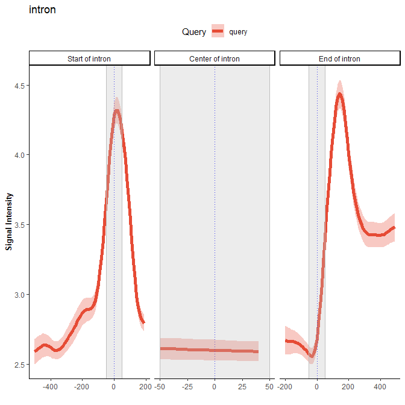

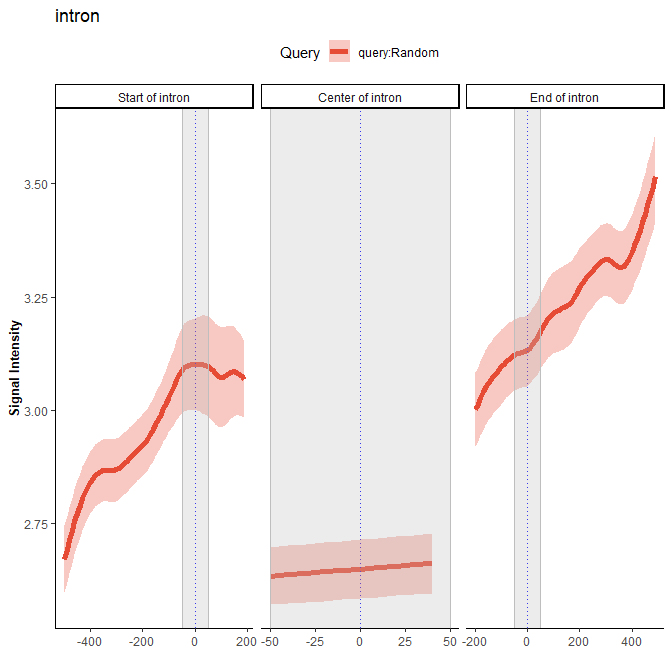

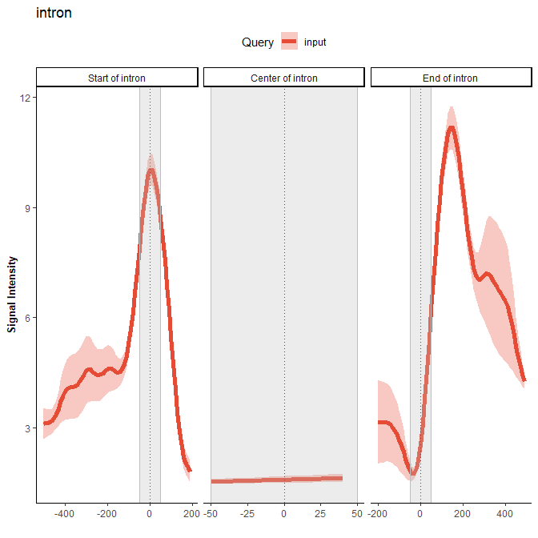

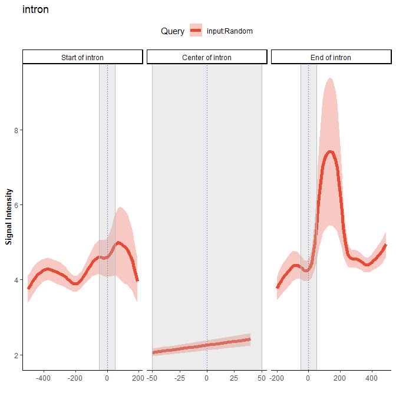

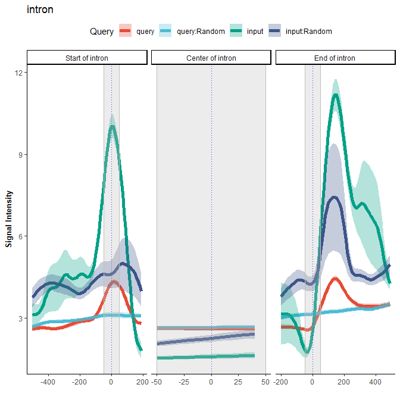

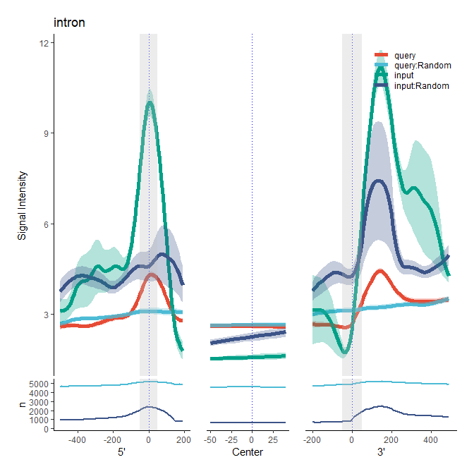

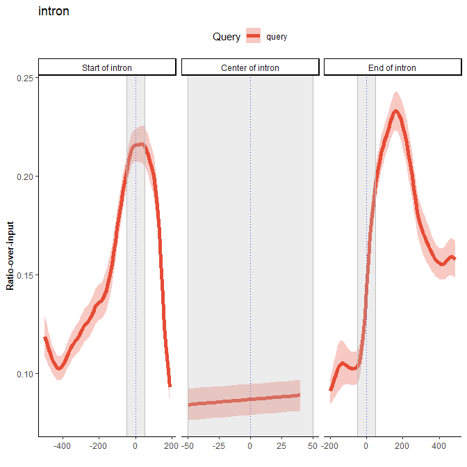

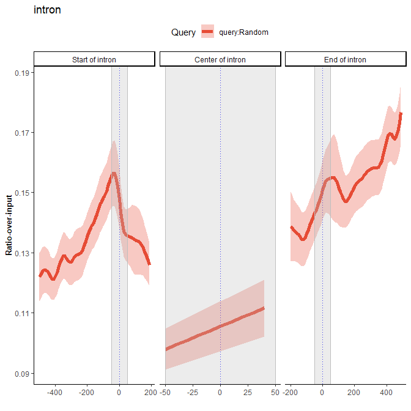

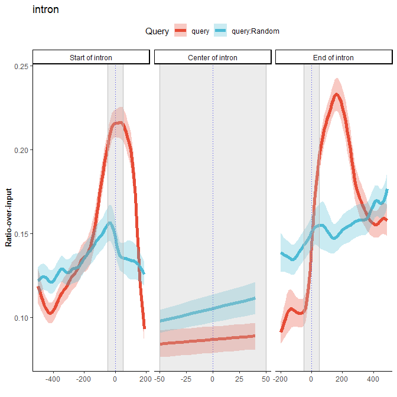

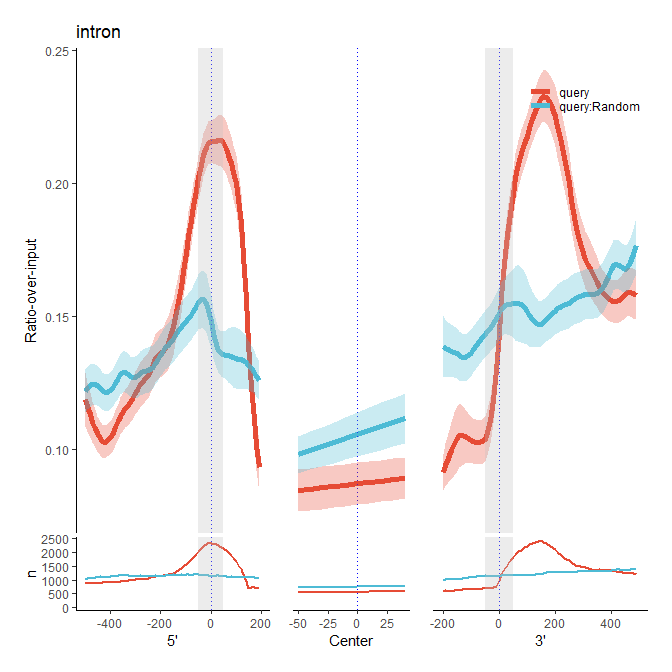

```r
txdb <- AnnotationDbi::loadDb(system.file("data", "txdb_chr19.sql", package="GenomicPlotData"))
queryfiles <- system.file("data", "test_clip_chr19.bam", package="GenomicPlotData")
names(queryfiles) <- "query"
inputfiles <- system.file("data", "test_clip_input_chr19.bam", package="GenomicPlotData")
names(inputfiles) <- "input"
ext <- c(-500, 200, -200, 500)
hl <- c(-50, 50, -50, 50)

handleInputParams <- list(CLIP_reads=FALSE, fix_width=150, fix_point="start", norm=TRUE, useScore=FALSE,
                          outRle=TRUE, useSizeFactor=TRUE, genome="hg19")
plot_start_end_feature(queryfiles=queryfiles, inputfiles=inputfiles, txdb=txdb, featureName="intron",
                       binsize=10,handleInputParams=handleInputParams, longest=TRUE, ext=ext, hl=hl,
                       randomize=TRUE, insert=100, stranded=TRUE, scale=FALSE, smooth=TRUE,
                       outPrefix=NULL, nc=5)
```

## Plot reference locus

Difference in signal intensity within specific regions around the reference loci can be tested, and the test statistics can be plotted as boxplot and barplot of mean +/- SE. The test can be done among loci or among samples.